# DATATHON Final Project: Impact of historical greenhouse emissions on fish response: United States, a case study

Lesly

2024-12-17

# Introduction

- Climate change poses a persistent threat to fish and their habitats across North America, because of their effect on streamflows, water temperature, salinity, and habitat connectivity (Paukert et al., 2021).
- Climate change effects impact fish by altering their physiology, disrupting spawning patterns, leading to extinctions, invasions and overall, altering community structures (Paukert et al., 2021).
- In the U.S., rising stream temperatures and altered precipitation patterns will reduce coldwater fish habitats by up to 50% by 2100 under high-emission scenarios. (R. Jones et al., 2012).
- Fisheries, including artisanal and recreational, may struggle to meet demands, impacting food security in developing countries and significant economic losses in developed countries (Ficke et al., 2007).
- Addressing climate impacts on U.S. fisheries requires proactive strategies, such as reducing other environmental stressors, while global efforts to cut greenhouse gas emissions continue (Ficke et al., 2007).
- **Objective**: Analyze the relationship between historical emissions of CO₂, CH₄, and N₂O and fish response to climate change using publicly available datasets.
- **Research Question**: How do historical greenhouse gas emissions (standardized to CO₂ equivalents) influence fish responses in the United States?

# Methodology

**Data sources**: National contributions to climate change due to historical emissions of carbon dioxide, methane, and nitrous oxide from 1830 to 2023 were obtained from (Jones et al., 2023), in an Excel document.

```r
emissions_data <- read_excel("USA Emissions.xlsx")
head(emissions_data)
```

```
## # A tibble: 6 × 7
##   CNTR_NAME ISO3  Gas   Component  Year  Data Unit
##   <chr>     <chr> <chr> <chr>     <dbl> <dbl> <chr>
## 1 USA       USA   CH[4] Fossil     1830 0.796 Tg~CH[4]~year^-1
## 2 USA       USA   CH[4] Fossil     1831 0.820 Tg~CH[4]~year^-1
## 3 USA       USA   CH[4] Fossil     1832 0.847 Tg~CH[4]~year^-1
## 4 USA       USA   CH[4] Fossil     1833 0.872 Tg~CH[4]~year^-1
## 5 USA       USA   CH[4] Fossil     1834 0.895 Tg~CH[4]~year^-1
## 6 USA       USA   CH[4] Fossil     1835 0.922 Tg~CH[4]~year^-1
```

Fish and climate change data were obtained from the FiCli website, which is a site that provides a comprehensive database of peer-reviewed literature available on how climate change has impacted inland fishes worldwide.The only filter used were country “United States”. The document was download in a csv format.

```r
fish_data <- read_csv("database (3).csv")
```

```
## ──────────────────────────────────────────────────────── Delimiter: "," chr
## (27): Author, Title, Journal, DOI or ISSN or Link, Documented or Project... dbl
## (3): ...1, Publication Date, Year
```

```r
head(fish_data)
```

```
## # A tibble: 6 × 30
##    ...1 Author          Title   `Publication Date` Journal `DOI or ISSN or Link`
##   <dbl> <chr>           <chr>                <dbl> <chr>   <chr>
## 1     1 Quinn and Adams Enviro…               1996 Ecology 10.2307/2265584
## 2     2 Quinn and Adams Enviro…               1996 Ecology 10.2307/2265584
## 3     3 Quinn et al.    Temper…               1997 Canadi… 10.1139/f97-038
## 4     4 Juanes et al.   Long-t…               2004 Canadi… 10.1139/f04-207
## 5     5 Juanes et al.   Long-t…               2004 Canadi… 10.1139/f04-207
## 6     6 Juanes et al.   Long-t…               2004 Canadi… 10.1139/f04-207
## # ℹ 24 more variables: `Documented or Projected` <chr>,
## #   `Date Range of Study` <chr>, Year <dbl>, `Study Area` <chr>,
## #   `Continent or Region` <chr>, Country <chr>, `Freshwater Ecoregion` <chr>,
## #   `Major Habitat Type` <chr>, `Waterbody Type` <chr>,
## #   `Lentic or Lotic` <chr>, `Climate Change Variable` <chr>,
## #   `Focal Species or Assemblage` <chr>, `Additional Species` <chr>,
## #   `Response Category` <chr>, `Response Variable` <chr>, …
```

```r
colnames(fish_data)
```

```
##  [1] "...1"
##  [2] "Author"
##  [3] "Title"
##  [4] "Publication Date"
##  [5] "Journal"
##  [6] "DOI or ISSN or Link"
##  [7] "Documented or Projected"
##  [8] "Date Range of Study"
##  [9] "Year"
## [10] "Study Area"
## [11] "Continent or Region"
## [12] "Country"
## [13] "Freshwater Ecoregion"
## [14] "Major Habitat Type"
## [15] "Waterbody Type"
## [16] "Lentic or Lotic"
## [17] "Climate Change Variable"
## [18] "Focal Species or Assemblage"
## [19] "Additional Species"
## [20] "Response Category"
## [21] "Response Variable"
## [22] "Fish_Response"
## [23] "Thermal Guild"
## [24] "Family or Fish Assemblage"
## [25] "Feeding Type"
## [26] "Feeding Habit"
## [27] "Reproductive Guild - Parental Care"
## [28] "Reproductive Guild - Pattern of Care"
## [29] "Binary Response"
## [30] "Management Recommendations"
```

**Standardization of greenhouse gas emissions**: To analyze emissions uniformly, all gases were converted to CO₂ equivalents (Tg/year) using global warming potentials (GWPs) (Pittelkow et al., 2013):

CH₄ (Methane): GWP = 25, N₂O (Nitrous Oxide): GWP = 298, CO₂: Directly converted from Pg to Tg by multiplying by 1,000.

All gases were added in order to have a total in CO₂ equivalents by year.

```r
emissions_data <- emissions_data %>%
  mutate(
    CH4_in_CO2eq = if_else(Gas == "CH[4]", Data * 25, 0),
    N2O_in_CO2eq = if_else(Gas == "N[2]*O", Data * 298, 0),
    CO2_in_CO2eq = if_else(Gas == "CO[2]", Data * 1000, 0),
    Total_CO2eq = CH4_in_CO2eq + N2O_in_CO2eq + CO2_in_CO2eq
  ) %>%
  group_by(Year) %>%
  summarize(Total_CO2eq = sum(Total_CO2eq, na.rm = TRUE))
head(emissions_data)
```

```
## # A tibble: 6 × 2
##    Year Total_CO2eq
##   <dbl>       <dbl>
## 1  1830        119.
## 2  1831        122.
## 3  1832        127.
## 4  1833        132.
## 5  1834        134.
## 6  1835        140.
```

**Data integration**: The emissions dataset was merged with the fish response dataset based on the “Year” variable. As fish response data ranged from 1964–2020 with gaps, the merged dataset only included overlapping years with available data from both sources.

```r
merged_data <- fish_data %>%
  mutate(Fish_Response = as.factor(Fish_Response)) %>%
  inner_join(emissions_data, by = "Year")
```

**Explanatory Data Analysis**: **I) Emissions Time Series**: Emissions data were visualized using animated time-series plot to highlight trends in CO₂-equivalent emissions over time.

```
## `geom_line()`: Each group consists of only one observation.
## ℹ Do you need to adjust the group aesthetic?
## `geom_line()`: Each group consists of only one observation.
## ℹ Do you need to adjust the group aesthetic?
```

[figure not shown]

```r
ggplot(emissions_data, aes(x = Year, y = Total_CO2eq)) +
  geom_line(color = "blue") +
  labs(
    title = "Animated Emissions Over Time",
    x = "Year",
    y = "Total CO2eq (Tg/year)"
  ) +
  transition_reveal(Year) +
  theme_minimal()
```

**II) Fish response** Fish response categories were summarized to identify the distribution of responses.

```r
fish_data %>% count(Fish_Response)
```

```
## # A tibble: 10 × 2
##    Fish_Response                       n
##    <chr>                           <int>
##  1 decrease                           71
##  2 earlier                             1
##  3 earlier migration                  18
##  4 earlier spawn timing                3
##  5 increase                           57
##  6 later date of redd construction     1
##  7 later migration                     4
##  8 no change                          49
##  9 synchrony of migration              1
## 10 variable                           21
```

**Statistical Analysis**: A logistic regression model was employed to examine the relationship between total CO₂-equivalent emissions (predictor variable) and fish response categories (dependent variable).

- *Dependent Variable*: Fish responses, categorized into various behavioral and population-level outcomes.
- *Predictor Variable*: Total CO₂-equivalent emissions (Tg/year), calculated as the sum of greenhouse gas emissions standardized using global warming potentials (GWPs).

```r
model <- glm(Fish_Response ~ Total_CO2eq,
             data = merged_data,
             family = "binomial")
```

# Results

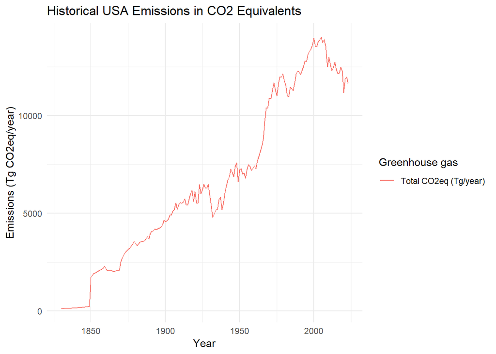

```r
ggplot(emissions_data, aes(x = Year)) +
  geom_line(aes(y = Total_CO2eq, color = "Total CO2eq (Tg/year)")) +
  labs(
    title = "Historical USA Emissions in CO2 Equivalents",
    x = "Year",
    y = "Emissions (Tg CO2eq/year)",
    color = "Greenhouse gas"
  ) +
  theme_minimal()
```

**Fish Response**: Each bar represents the count of observations for a specific category of fish response, taller bars indicate more frequent responses in that category.The categorical distribution of fish responses suggests potential patterns in relation to emissions.The fish response data indicate varying responses to climate change, with categories such as “increase,” “decrease,” and “no change” being most prominent.

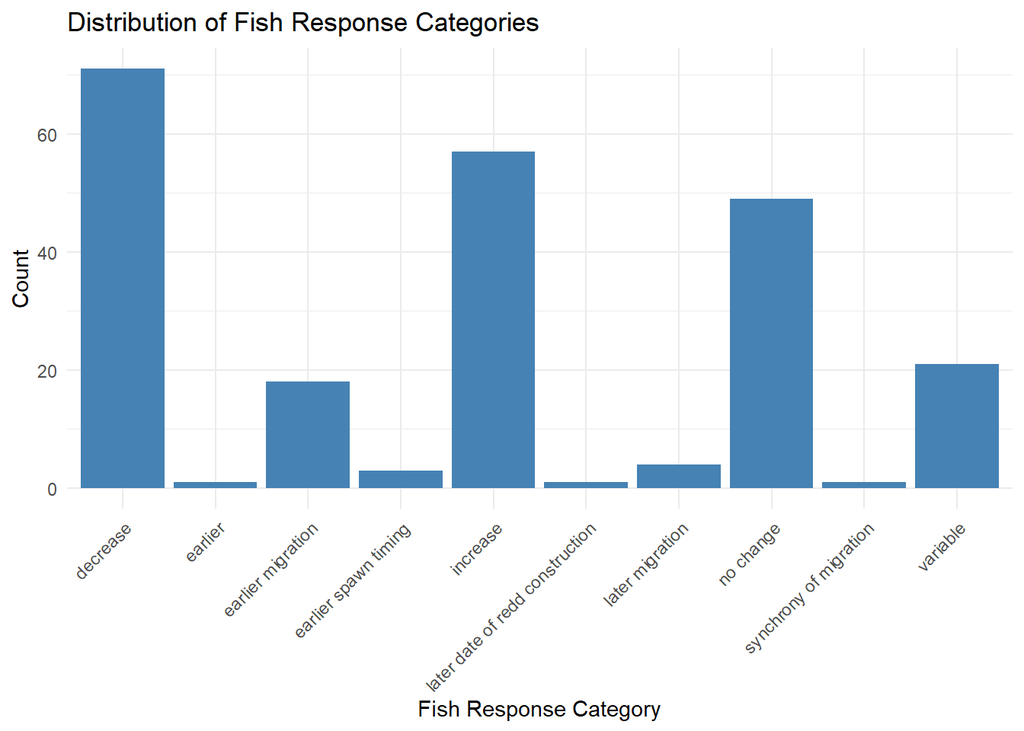

```r
ggplot(fish_data, aes(x = Fish_Response)) +
  geom_bar(fill = "steelblue") +
  labs(
    title = "Distribution of Fish Response Categories",
    x = "Fish Response Category",
    y = "Count"
  ) +
  theme_minimal() +
  theme(
    axis.text.x = element_text(angle = 45, hjust = 1)
  )
```

*Interpretation of Results*

-Slope for Total_CO2eq (-0.0005484):The negative coefficient suggests an inverse relationship between Total_CO2eq and the odds of the Fish_Response category being in a particular state.For every unit increase in Total_CO2eq, the log-odds of the response decrease by 0.0005484.

-Significance (Pr(>|z|) = 0.009):The p-value indicates that the relationship between Total_CO2eq and Fish_Response is statistically significant at the 1% level.This suggests a non-random relationship between emissions and fish responses.

```r
summary(model)
```

```
##
## Call:
## glm(formula = Fish_Response ~ Total_CO2eq, family = "binomial",
##     data = merged_data)
##
## Coefficients:
##               Estimate Std. Error z value Pr(>|z|)
## (Intercept)  7.6446992  2.6434931   2.892  0.00383 **
## Total_CO2eq -0.0005484  0.0002100  -2.612  0.00900 **
## ---
## Signif. codes:  0 '***' 0.001 '**' 0.01 '*' 0.05 '.' 0.1 ' ' 1
##
## (Dispersion parameter for binomial family taken to be 1)
##
##     Null deviance: 281.32  on 225  degrees of freedom
## Residual deviance: 273.66  on 224  degrees of freedom
## AIC: 277.66
##
## Number of Fisher Scoring iterations: 4
```

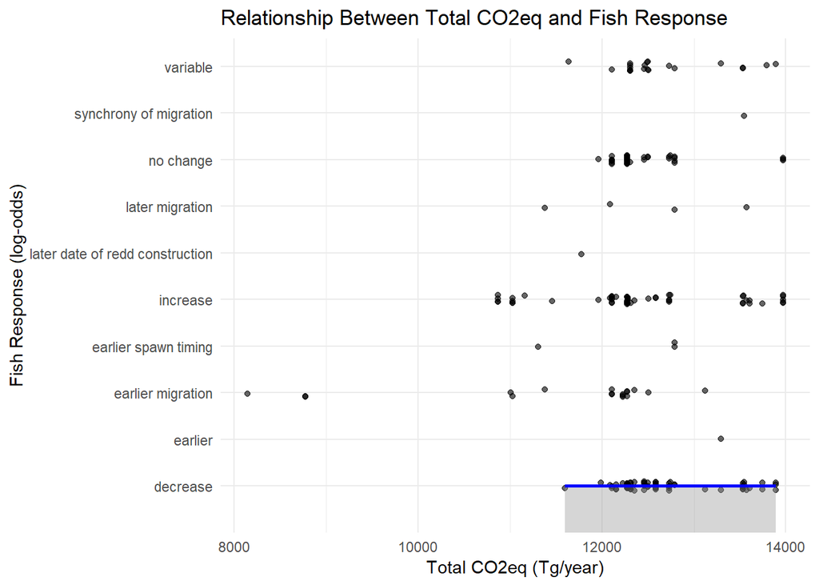

```r
ggplot(merged_data, aes(x = Total_CO2eq, y = Fish_Response)) +
  geom_jitter(width = 0.1, height = 0.1, alpha = 0.6) +
  geom_smooth(method = "glm", method.args = list(family = "binomial"), color = "blue") +
  labs(
    title = "Relationship Between Total CO2eq and Fish Response",
    x = "Total CO2eq (Tg/year)",
    y = "Fish Response (log-odds)"
  ) +
  theme_minimal()
```

# Discussion

-Fish responses such as earlier migrations or reduced populations can disrupt food webs, threaten biodiversity, and challenge conservation efforts. These ecological shifts could have negative effects on human food security and economic stability.

# Conclusions

**Limitations** The analysis identifies correlations but cannot establish causation. Experimental studies could provide deeper insights into causal relationships.

# References

1. Ficke, A. D., Myrick, C. A., & Hansen, L. J. (2007). Potential impacts of global climate change on freshwater fisheries. Reviews in Fish Biology and Fisheries, 17(4), 581–613. https://doi.org/10.1007/s11160-007-9059-5
2. Fish and Climate Change Database (FICLI). (n.d.). https://rconnect.usgs.gov/ficli/
3. Henriques, S. T., & Borowiecki, K. J. (2016). The drivers of long-run CO2 emissions in Europe, North America and Japan since 1800. Energy Policy, 101, 537–549. https://doi.org/10.1016/j.enpol.2016.11.005
4. Jones, M. W., Peters, G. P., Gasser, T., Andrew, R. M., Schwingshackl, C., Gütschow, J., Houghton, R. A., Friedlingstein, P., Pongratz, J., & Quéré, C. L. (2023). National contributions to climate change due to historical emissions of carbon dioxide, methane, and nitrous oxide since 1850. Scientific Data, 10(1). https://doi.org/10.1038/s41597-023-02041-1
5. Jones, R., Travers, C., Rodgers, C., Lazar, B., English, E., Lipton, J., Vogel, J., Strzepek, K., & Martinich, J. (2012). Climate change impacts on freshwater recreational fishing in the United States. Mitigation and Adaptation Strategies for Global Change, 18(6), 731–758. https://doi.org/10.1007/s11027-012-9385-3
6. Krabbenhoft, T. J., Myers, B. J. E., Wong, J. P., Chu, C., Tingley, R. W., Falke, J. A., Kwak, T. J., Paukert, C. P., & Lynch, A. J. (2020). FiCli, the Fish and Climate Change Database, informs climate adaptation and management for freshwater fishes. Scientific Data, 7(1). https://doi.org/10.1038/s41597-020-0465-z
7. Pittelkow, C. M., Adviento-Borbe, M. A., Hill, J. E., Six, J., Van Kessel, C., & Linquist, B. A. (2013). Yield-scaled global warming potential of annual nitrous oxide and methane emissions from continuously flooded rice in response to nitrogen input. Agriculture Ecosystems & Environment, 177, 10–20. https://doi.org/10.1016/j.agee.2013.05.011